# Tugas Akhir Kelompok-4 (UGM04)

1. Teguh Nurhadi Suharsono
2. Peti Savitri
3. Timothy John Pattiasina

## Visualisasi Data Perpustakaan:

1. Data Sumber (Asli)
2. Data Preparation & Cleansing

Deskripsi: Data yang diperoleh dari DISPUSIP DKI JAKARTA adalah data pengunjung perpustakaan (source:https://data.jakarta.go.id/dataset/data-jumlah-pengunjung-perpustakaan-di-dki-jakarta) Dataset ini berisi rekapitulasi jumlah pengunjung perpustakaan daerah Provinsi DKI Jakarta per tahun. Penjelasan mengenai variabel pada dataset ini:

tahun : Tahun jenis : Jenis perpustakaan : Nama Perpustakaan jumlah : Jumlah Pengunjung Dataset ini berasal dari tahun 2015 s.d. 2019.

```python
#1
import pandas as pd
import matplotlib.pyplot as plt
path = "D:/finalsimplelinreg-main/data-jumlah-pengunjung-perpustakaan-tahun-2015-2019.csv"
df = pd.read_csv(path)
df.head(115)
```

|  | tahun | perpustakaan | jumlah | tahun.1 | perpustakaan.1 | jumlah.1 | tahun.2 | perpustakaan.2 | jumlah.2 | tahun.3 | perpustakaan.3 | jumlah.3 | tahun.4 | perpustakaan.4 | jumlah.4 |
| --- | --- | --- | --- | --- | --- | --- | --- | --- | --- | --- | --- | --- | --- | --- | --- |
| 0 | 2015 | Cikini | 72758.0 | 2016 | Cikini | 103341.0 | 2017 | Cikini | 83619.0 | 2018 | Cikini | 79114 | 2019 | Cikini | 62895 |
| 1 | 2015 | Kuningan | 13529.0 | 2016 | Kuningan | 68654.0 | 2017 | Kuningan | 53821.0 | 2018 | Kuningan | 5447 | 2019 | Kuningan | 45230 |
| 2 | 2015 | PDS HB Jassin | 0.0 | 2016 | PDS HB Jassin | 0.0 | 2017 | PDS HB Jassin | 0.0 | 2018 | PDS HB Jassin | 2749 | 2019 | PDS HB Jassin | 5319 |
| 3 | 2015 | Perpustakaan Digital iJakarta | 0.0 | 2016 | Perpustakaan Digital iJakarta | 0.0 | 2017 | Perpustakaan Digital iJakarta | 0.0 | 2018 | Perpustakaan Digital iJakarta | 20736 | 2019 | Perpustakaan Digital iJakarta | 21999 |
| 4 | 2015 | Sudin Pusip Jakpus (Stationary) | 15108.0 | 2016 | Sudin Pusip Jakpus (Stationary) | 91807.0 | 2017 | Sudin Pusip Jakpus (Stationary) | 20411.0 | 2018 | Sudin Pusip Jakpus (Stationary) | 23719 | 2019 | Sudin Pusip Jakpus (Stationary) | 36767 |
| 5 | 2015 | Sudin Pusip Jakpus (Pusling) | 24717.0 | 2016 | Sudin Pusip Jakpus (Pusling) | 64336.0 | 2017 | Sudin Pusip Jakpus (Pusling) | 105747.0 | 2018 | Sudin Pusip Jakpus (Pusling) | 154044 | 2019 | Sudin Pusip Jakpus (Pusling) | 196689 |
| 6 | 2015 | Sudin Pusip Jakpus (RPTRA) | 0.0 | 2016 | Sudin Pusip Jakpus (RPTRA) | 43152.0 | 2017 | Sudin Pusip Jakpus (RPTRA) | 0.0 | 2018 | Sudin Pusip Jakpus (RPTRA) | 219972 | 2019 | Sudin Pusip Jakpus (RPTRA) | 357184 |
| 7 | 2015 | Sudin Pusip Jaktim (Stationary) | 13211.0 | 2016 | Sudin Pusip Jaktim (Stationary) | 17755.0 | 2017 | Sudin Pusip Jaktim (Stationary) | 2877.0 | 2018 | Sudin Pusip Jaktim (Stationary) | 22891 | 2019 | Sudin Pusip Jaktim (Stationary) | 29159 |
| 8 | 2015 | Sudin Pusip Jaktim (Pusling) | 47509.0 | 2016 | Sudin Pusip Jaktim (Pusling) | 46829.0 | 2017 | Sudin Pusip Jaktim (Pusling) | 46985.0 | 2018 | Sudin Pusip Jaktim (Pusling) | 135195 | 2019 | Sudin Pusip Jaktim (Pusling) | 279240 |
| 9 | 2015 | Sudin Pusip Jaktim (RPTRA) | 0.0 | 2016 | Sudin Pusip Jaktim (RPTRA) | 101456.0 | 2017 | Sudin Pusip Jaktim (RPTRA) | 0.0 | 2018 | Sudin Pusip Jaktim (RPTRA) | 39194 | 2019 | Sudin Pusip Jaktim (RPTRA) | 363273 |
| 10 | 2015 | Sudin Pusip Jakbar (Stationary) | 28384.0 | 2016 | Sudin Pusip Jakbar (Stationary) | 26211.0 | 2017 | Sudin Pusip Jakbar (Stationary) | 32509.0 | 2018 | Sudin Pusip Jakbar (Stationary) | 47328 | 2019 | Sudin Pusip Jakbar (Stationary) | 45374 |
| 11 | 2015 | Sudin Pusip Jakbar (Pusling) | 0.0 | 2016 | Sudin Pusip Jakbar (Pusling) | 53413.0 | 2017 | Sudin Pusip Jakbar (Pusling) | 66570.0 | 2018 | Sudin Pusip Jakbar (Pusling) | 237715 | 2019 | Sudin Pusip Jakbar (Pusling) | 234853 |
| 12 | 2015 | Sudin Pusip Jakbar (RPTRA) | 0.0 | 2016 | Sudin Pusip Jakbar (RPTRA) | 142919.0 | 2017 | Sudin Pusip Jakbar (RPTRA) | 0.0 | 2018 | Sudin Pusip Jakbar (RPTRA) | 511065 | 2019 | Sudin Pusip Jakbar (RPTRA) | 461598 |
| 13 | 2015 | Sudin Pusip Jaksel (Stationary) | 18956.0 | 2016 | Sudin Pusip Jaksel (Stationary) | 25662.0 | 2017 | Sudin Pusip Jaksel (Stationary) | 28923.0 | 2018 | Sudin Pusip Jaksel (Stationary) | 28955 | 2019 | Sudin Pusip Jaksel (Stationary) | 34063 |
| 14 | 2015 | Sudin Pusip Jaksel (Pusling) | 18690.0 | 2016 | Sudin Pusip Jaksel (Pusling) | 25040.0 | 2017 | Sudin Pusip Jaksel (Pusling) | 57755.0 | 2018 | Sudin Pusip Jaksel (Pusling) | 683 | 2019 | Sudin Pusip Jaksel (Pusling) | 165535 |
| 15 | 2015 | Sudin Pusip Jaksel (RPTRA) | 0.0 | 2016 | Sudin Pusip Jaksel (RPTRA) | 42385.0 | 2017 | Sudin Pusip Jaksel (RPTRA) | 0.0 | 2018 | Sudin Pusip Jaksel (RPTRA) | 475141 | 2019 | Sudin Pusip Jaksel (RPTRA) | 459210 |
| 16 | 2015 | Sudin Pusip Jakut (Stationary) | 18548.0 | 2016 | Sudin Pusip Jakut (Stationary) | 43966.0 | 2017 | Sudin Pusip Jakut (Stationary) | 22027.0 | 2018 | Sudin Pusip Jakut (Stationary) | 37791 | 2019 | Sudin Pusip Jakut (Stationary) | 32717 |
| 17 | 2015 | Sudin Pusip Jakut (Pusling) | 20609.0 | 2016 | Sudin Pusip Jakut (Pusling) | 40712.0 | 2017 | Sudin Pusip Jakut (Pusling) | 77320.0 | 2018 | Sudin Pusip Jakut (Pusling) | 109919 | 2019 | Sudin Pusip Jakut (Pusling) | 107136 |
| 18 | 2015 | Sudin Pusip Jakut (RPTRA) | 0.0 | 2016 | Sudin Pusip Jakut (RPTRA) | 21298.0 | 2017 | Sudin Pusip Jakut (RPTRA) | 0.0 | 2018 | Sudin Pusip Jakut (RPTRA) | 691603 | 2019 | Sudin Pusip Jakut (RPTRA) | 534462 |
| 19 | 2015 | Sudin Pusip Pulau 1000 (Stationary) | 8579.0 | 2016 | Sudin Pusip Pulau 1000 (Stationary) | 48376.0 | 2017 | Sudin Pusip Pulau 1000 (Stationary) | 58916.0 | 2018 | Sudin Pusip Pulau 1000 (Stationary) | 65658 | 2019 | Sudin Pusip Pulau 1000 (Stationary) | 51743 |
| 20 | 2015 | Sudin Pusip Pulau 1000 (RPTRA) | 0.0 | 2016 | Sudin Pusip Pulau 1000 (RPTRA) | 6200.0 | 2017 | Sudin Pusip Pulau 1000 (RPTRA) | 0.0 | 2018 | Sudin Pusip Pulau 1000 (RPTRA) | 136589 | 2019 | Sudin Pusip Pulau 1000 (RPTRA) | 147097 |
| 21 | 2015 | Permata 1 | 7549.0 | 2016 | Permata 1 | 11161.0 | 2017 | Permata 1 | 18139.0 | 2018 | Permata 1 | 9778 | 2019 | Permata 1 | 6623 |
| 22 | 2015 | Permata 2 | 3819.0 | 2016 | Permata 2 | 10779.0 | 2017 | Permata 2 | 18223.0 | 2018 | Permata 2 | 10538 | 2019 | Permata 2 | 10524 |

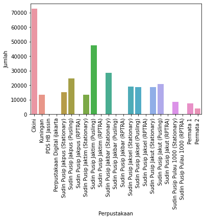

```python
import seaborn as sns
import pandas as pd
import numpy as np
import matplotlib.pyplot as plt
path = "D:/finalsimplelinreg-main/data-jumlah-pengunjung-perpustakaan-tahun-2015-2019.csv"
df = pd.read_csv(path)
sns.barplot(data=df, x="perpustakaan", y="jumlah")
plt.xlabel('Perpustakaan')
plt.ylabel('Jumlah')
plt.xticks(rotation = 90)
plt.show()
```

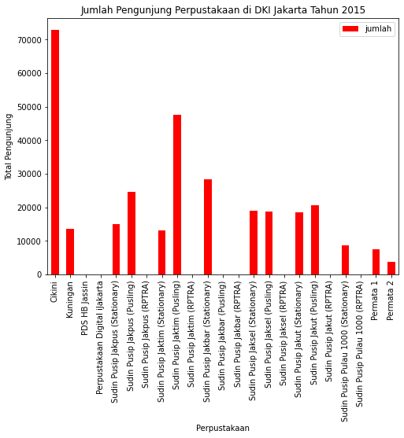

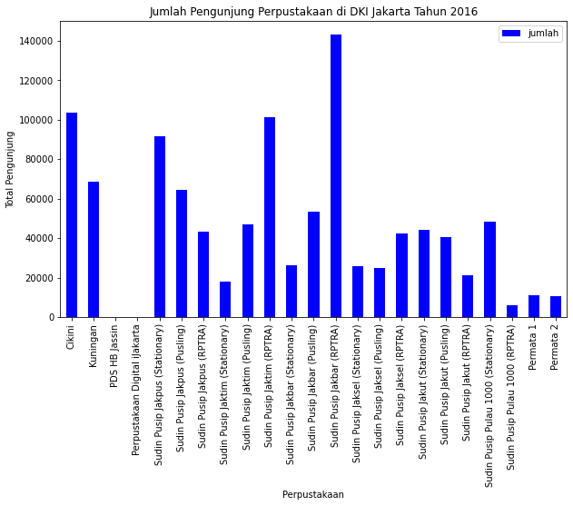

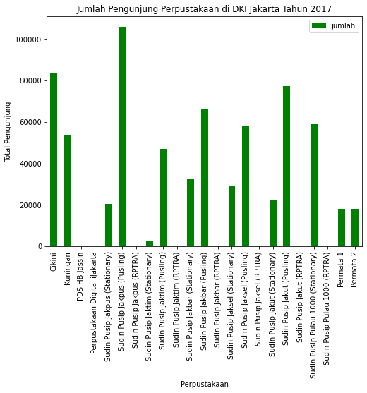

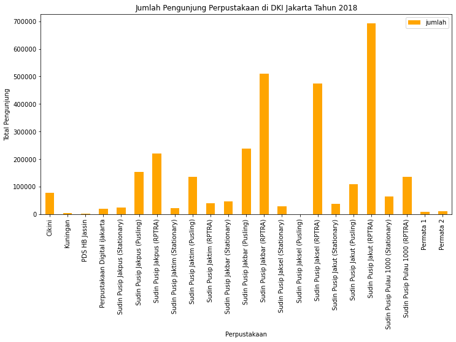

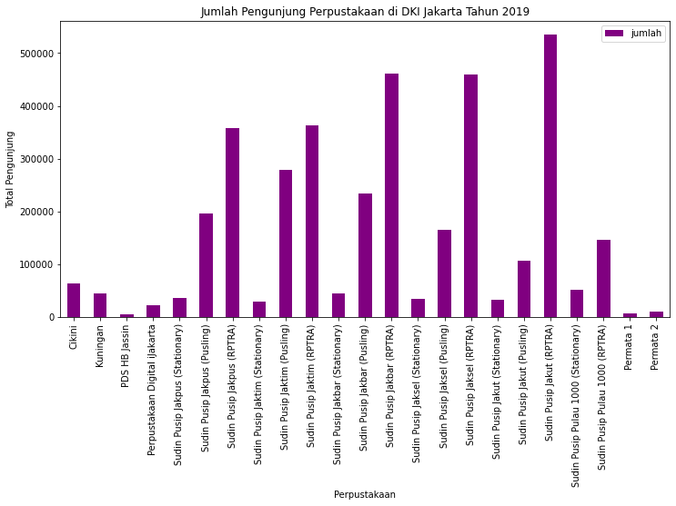

```python
import pandas as pd
import numpy as np
import matplotlib.pyplot as plt
import pandas as pd
import os
os.chdir('D:/finalsimplelinreg-main/')
# Visualisasi Data Pengunjung Perpustakaan di DKI Jakarta Tahun 2015
path1 = "data-jumlah-pengunjung-perpustakaan-tahun-2015.csv"
df1 = pd.read_csv(path1)
df1.plot.bar(x='perpustakaan', y='jumlah', rot=0, figsize=(8, 6), color='red')
plt.xlabel('Perpustakaan')
plt.xticks(rotation=90)
plt.ylabel('Total Pengunjung')
plt.title('Jumlah Pengunjung Perpustakaan di DKI Jakarta Tahun 2015')

# Visualisasi Data Pengunjung Perpustakaan di DKI Jakarta Tahun 2016
path2 = "data-jumlah-pengunjung-perpustakaan-tahun-2016.csv"
df2 = pd.read_csv(path2)
df2.plot.bar(x='perpustakaan', y='jumlah', rot=0, figsize=(10, 6), color='blue')
plt.xlabel('Perpustakaan')
plt.xticks(rotation=90)
plt.ylabel('Total Pengunjung')
plt.title('Jumlah Pengunjung Perpustakaan di DKI Jakarta Tahun 2016')

# Visualisasi Data Pengunjung Perpustakaan di DKI Jakarta Tahun 2017
path3 = "data-jumlah-pengunjung-perpustakaan-tahun-2017.csv"
df3 = pd.read_csv(path3)
df3.plot.bar(x='perpustakaan', y='jumlah', rot=0, figsize=(8, 6), color='green')
plt.xlabel('Perpustakaan')
plt.xticks(rotation=90)
plt.ylabel('Total Pengunjung')
plt.title('Jumlah Pengunjung Perpustakaan di DKI Jakarta Tahun 2017')

# Visualisasi Data Pengunjung Perpustakaan di DKI Jakarta Tahun 2018
path4 = "data-jumlah-pengunjung-perpustakaan-tahun-2018.csv"
df4 = pd.read_csv(path4)
df4.plot.bar(x='perpustakaan', y='jumlah', rot=0, figsize=(12, 6), color='orange')
plt.xlabel('Perpustakaan')
plt.xticks(rotation=90)
plt.ylabel('Total Pengunjung')
plt.title('Jumlah Pengunjung Perpustakaan di DKI Jakarta Tahun 2018')

# Visualisasi Data Pengunjung Perpustakaan di DKI Jakarta Tahun 2019
path5 = "data-jumlah-pengunjung-perpustakaan-tahun-2019.csv"
df5 = pd.read_csv(path5)
df5.plot.bar(x='perpustakaan', y='jumlah', rot=0, figsize=(12, 6), color='purple')
plt.xlabel('Perpustakaan')
plt.xticks(rotation=90)
plt.ylabel('Total Pengunjung')
plt.title('Jumlah Pengunjung Perpustakaan di DKI Jakarta Tahun 2019')

plt.show()
```

```python
dataset = pd.read_csv('perpusdacikinikuningan2015-2019.csv')
X = dataset.iloc[:, [0, 2]].values
X_df = dataset[["tahun",  "jumlah"]]
X_df.head(10)
```

|  | tahun | jumlah |
| --- | --- | --- |
| 0 | 2015 | 72758.0 |
| 1 | 2016 | 103341.0 |
| 2 | 2019 | 62895.0 |
| 3 | 2017 | 83619.0 |
| 4 | 2018 | 79114.0 |
| 5 | 2015 | 13529.0 |
| 6 | 2016 | 68654.0 |
| 7 | 2019 | 45230.0 |
| 8 | 2018 | 5447.0 |
| 9 | 2017 | 53821.0 |

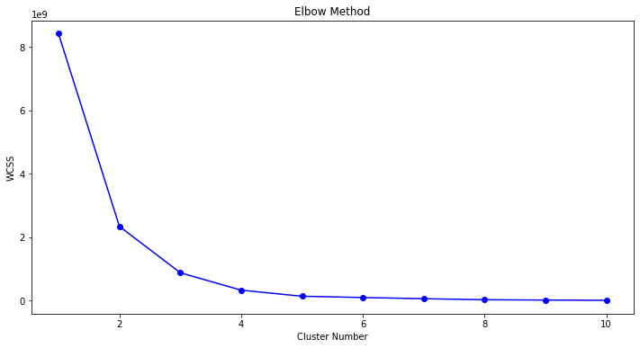

```python
# Menggunakan metode elbow untuk menentukan angka cluster yang tepat
from sklearn.cluster import KMeans
X = X_df.loc[:,["tahun", "jumlah"]]
wcss = []
k = range(1,11)
for i in k:
    means_k = KMeans(n_clusters=i, random_state=42)
    means_k.fit(X)
    wcss.append(means_k.inertia_)
plt.figure(figsize=(12,6))
plt.plot(k , wcss , 'bo-')
plt.title('Elbow Method')
plt.xlabel('Cluster Number')
plt.ylabel('WCSS')
plt.show()
```

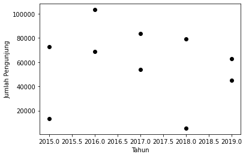

```python
# Menjalankan K-Means Clustering ke dataset
kmeans = KMeans(n_clusters = 3, init = 'k-means++', random_state = 0)
labels = kmeans.fit_predict(X_df)
X_df = X.copy()
X_df["Cluster"] = labels
#Memilih dua variabel dan visualisasikan titik datanya
X = X_df[["tahun", "jumlah"]]
plt.scatter(X["tahun"],X["jumlah"],c='black')
plt.xlabel('Tahun')
plt.ylabel('Jumlah Pengunjung')
plt.show()
```

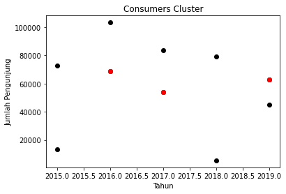

|  | tahun | jumlah | Cluster |
| --- | --- | --- | --- |
| 9 | 2017 | 53821.0 | 1 |
| 2 | 2019 | 62895.0 | 1 |
| 6 | 2016 | 68654.0 | 1 |

```python
#Menentukan jumlah clusters (K) dan pilih centroid secara acak untuk setiap cluster

K=3

#Pilih pengamatan acak sebagai centroid
Centroids = (X_df.sample(n=K))
plt.scatter(X_df["tahun"],X_df["jumlah"],c='black')
plt.scatter(Centroids["tahun"],Centroids["jumlah"],c='red')
plt.title('Consumers Cluster')
plt.xlabel('Tahun')
plt.ylabel('Jumlah Pengunjung')
plt.show()
Centroids[:]
```

Langkah berikutnya adalah menetapkan semua titik ke centroid cluster terdekat dan Hitung ulang centroid dari cluster yang baru terbentuk (dilakukan secara berulang)

```python
diff = 1
j=0

while(diff!=0):
    XD=X_df
    i=1
    for index1,row_c in Centroids.iterrows():
        ED=[]
        for index2,row_d in XD.iterrows():
            d1=(row_c["tahun"]-row_d["tahun"])**2
            d2=(row_c["jumlah"]-row_d["jumlah"])**2
            d=np.sqrt(d1+d2)
            ED.append(d)
        X_df[i]=ED
        i=i+1

    C=[]
    for index,row in X_df.iterrows():
        min_dist=row[1]
        pos=1
        for i in range(K):
            if row[i+1] < min_dist:
                min_dist = row[i+1]
                pos=i+1
        C.append(pos)
    X_df["Cluster"]=C
    Centroids_new = X_df.groupby(["Cluster"]).mean()[["jumlah","tahun"]]
    if j == 0:
        diff=1
        j=j+1
    else:
        diff = (Centroids_new['jumlah'] - Centroids['jumlah']).sum() + (Centroids_new['tahun'] - Centroids['tahun']).sum()
        print(diff.sum())
    Centroids = X_df.groupby(["Cluster"]).mean()[["jumlah","tahun"]]
```

```
-6000.433333333331
-9049.53333333334
0.0
```

Nilai-nilai ini mungkin berbeda setiap kali dijalankan. Training akan berhenti ketika centroid tidak berubah setelah dua iterasi. Awalnya didefinisikan diff = 1, kemudian didalam badan perulangan (while loop), dihitung perbedaan antara centroid pada iterasi sebelumnya dan iterasi saat ini. Training data akan berhenti ketika perbedaan sudah 0.

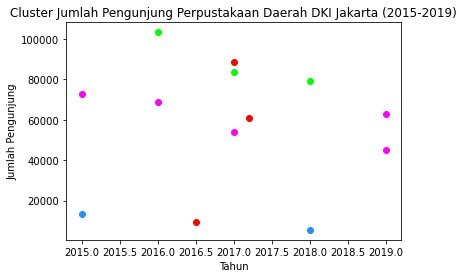

```python
#Visualiasasi cluster yang terbentuk
color=['dodgerblue','magenta', 'lime']
for k in range(K):
    data=X_df[X_df["Cluster"]==k+1]
    plt.scatter(data["tahun"],data["jumlah"],c=color[k])
plt.scatter(Centroids["tahun"],Centroids["jumlah"],c='red')
plt.title('Cluster Jumlah Pengunjung Perpustakaan Daerah DKI Jakarta (2015-2019)')
plt.xlabel('Tahun')
plt.ylabel('Jumlah Pengunjung')
plt.show()
```

Dari hasil diagram diatas, dapat dengan jelas memvisualisasikan 3 kelompok. Titik-titik merah mewakili pusat centroid dari setiap cluster. sedangkan titik hijau muda (lime), merah keunguan (magenta) dan biru muda (dodger blue) adalah representasi dari 3 cluster yang terbentuk

# Data Preparation & Cleansing

[figure not shown]

```python
import matplotlib.pyplot as plt
import numpy as np
import pandas as pd
from io import StringIO

path = "D:/finalsimplelinreg-main/data-jumlah-pengunjung-perpustakaan-tahun-2015-2019.csv"
df = pd.read_csv(path)

df.plot.bar(x='perpustakaan', y='jumlah', rot=0, figsize=(12, 6), color='purple')
plt.xlabel('Perpustakaan')
plt.xticks(rotation=90)
plt.ylabel('Total Pengunjung')
plt.title('Jumlah Pengunjung Perpustakaan di DKI Jakarta Tahun 2019')

plt.show()
```

[figure not shown]

```python
import numpy as np
import matplotlib.pyplot as plt

X = ['2015','2016','2017','2018', '2019']
cikini = [72758,103341,83619,79114,62895]
kuningan = [13529, 68654,53821,5447,45230]

X_axis = np.arange(len(X))

plt.bar(X_axis - 0.2, cikini, 0.4, label = 'Perpusda Cikini', color='green')
plt.bar(X_axis + 0.2, kuningan, 0.4, label = 'Perpusda Kuningan', color = 'pink')

plt.xticks(X_axis, X)
plt.xlabel("Tahun")
plt.ylabel("Total Pengunjung")
plt.title("Jumlah Pengunjung Perpustakaan di DKI Jakarta Tahun 2019")
plt.legend()
plt.show()
```

# Perbaikan Data

Missing Value: Berdasarkan data yang diperoleh, terdapat beberapa perbedaan antara data pelaporan pengunjung di tiap tahun, yaitu pada kolom nama perpustakaan. serta kolom jumlah pengunjung yang tidak sama antara satu dataset dengan yang lainnya. Hanya dataset tahun 2018 dan 2019 yang memiliki isian data lengkap pada 4 kolom yang ada. Untuk itu coba dilakukan imputasi guna mengganti nilai/data yang hilang (missing value; NaN; blank) dengan nilai pengganti, menggunakan teknik Imputasi Nilai Nol/Konstanta

```python
path1 = "data-jumlah-pengunjung-perpustakaan-tahun-2015.csv"
df1 = pd.read_csv(path1)
path2 = "data-jumlah-pengunjung-perpustakaan-tahun-2016.csv"
df2 = pd.read_csv(path2)
path3 = "data-jumlah-pengunjung-perpustakaan-tahun-2017.csv"
df3 = pd.read_csv(path3)
path4 = "data-jumlah-pengunjung-perpustakaan-tahun-2018.csv"
df4 = pd.read_csv(path4)
path5 = "data-jumlah-pengunjung-perpustakaan-tahun-2019.csv"
df5 = pd.read_csv(path5)
finaldf = pd.concat([df1, df2, df3, df4, df5], axis=1, join='inner').sort_index()
finaldf.fillna(0).to_csv("data-jumlah-pengunjung-perpustakaan-tahun-2015-2019.csv", index=False, encoding='utf-8-sig')
```

```python
finaldf.fillna(0)
```

|  | tahun | perpustakaan | jumlah | tahun | perpustakaan | jumlah | tahun | perpustakaan | jumlah | tahun | perpustakaan | jumlah | tahun | perpustakaan | jumlah |
| --- | --- | --- | --- | --- | --- | --- | --- | --- | --- | --- | --- | --- | --- | --- | --- |
| 0 | 2015 | Cikini | 72758.0 | 2016 | Cikini | 103341.0 | 2017 | Cikini | 83619.0 | 2018 | Cikini | 79114 | 2019 | Cikini | 62895 |
| 1 | 2015 | Kuningan | 13529.0 | 2016 | Kuningan | 68654.0 | 2017 | Kuningan | 53821.0 | 2018 | Kuningan | 5447 | 2019 | Kuningan | 45230 |
| 2 | 2015 | PDS HB Jassin | 0.0 | 2016 | PDS HB Jassin | 0.0 | 2017 | PDS HB Jassin | 0.0 | 2018 | PDS HB Jassin | 2749 | 2019 | PDS HB Jassin | 5319 |
| 3 | 2015 | Perpustakaan Digital iJakarta | 0.0 | 2016 | Perpustakaan Digital iJakarta | 0.0 | 2017 | Perpustakaan Digital iJakarta | 0.0 | 2018 | Perpustakaan Digital iJakarta | 20736 | 2019 | Perpustakaan Digital iJakarta | 21999 |
| 4 | 2015 | Sudin Pusip Jakpus (Stationary) | 15108.0 | 2016 | Sudin Pusip Jakpus (Stationary) | 91807.0 | 2017 | Sudin Pusip Jakpus (Stationary) | 20411.0 | 2018 | Sudin Pusip Jakpus (Stationary) | 23719 | 2019 | Sudin Pusip Jakpus (Stationary) | 36767 |
| 5 | 2015 | Sudin Pusip Jakpus (Pusling) | 24717.0 | 2016 | Sudin Pusip Jakpus (Pusling) | 64336.0 | 2017 | Sudin Pusip Jakpus (Pusling) | 105747.0 | 2018 | Sudin Pusip Jakpus (Pusling) | 154044 | 2019 | Sudin Pusip Jakpus (Pusling) | 196689 |
| 6 | 2015 | Sudin Pusip Jakpus (RPTRA) | 0.0 | 2016 | Sudin Pusip Jakpus (RPTRA) | 43152.0 | 2017 | Sudin Pusip Jakpus (RPTRA) | 0.0 | 2018 | Sudin Pusip Jakpus (RPTRA) | 219972 | 2019 | Sudin Pusip Jakpus (RPTRA) | 357184 |
| 7 | 2015 | Sudin Pusip Jaktim (Stationary) | 13211.0 | 2016 | Sudin Pusip Jaktim (Stationary) | 17755.0 | 2017 | Sudin Pusip Jaktim (Stationary) | 2877.0 | 2018 | Sudin Pusip Jaktim (Stationary) | 22891 | 2019 | Sudin Pusip Jaktim (Stationary) | 29159 |
| 8 | 2015 | Sudin Pusip Jaktim (Pusling) | 47509.0 | 2016 | Sudin Pusip Jaktim (Pusling) | 46829.0 | 2017 | Sudin Pusip Jaktim (Pusling) | 46985.0 | 2018 | Sudin Pusip Jaktim (Pusling) | 135195 | 2019 | Sudin Pusip Jaktim (Pusling) | 279240 |
| 9 | 2015 | Sudin Pusip Jaktim (RPTRA) | 0.0 | 2016 | Sudin Pusip Jaktim (RPTRA) | 101456.0 | 2017 | Sudin Pusip Jaktim (RPTRA) | 0.0 | 2018 | Sudin Pusip Jaktim (RPTRA) | 39194 | 2019 | Sudin Pusip Jaktim (RPTRA) | 363273 |
| 10 | 2015 | Sudin Pusip Jakbar (Stationary) | 28384.0 | 2016 | Sudin Pusip Jakbar (Stationary) | 26211.0 | 2017 | Sudin Pusip Jakbar (Stationary) | 32509.0 | 2018 | Sudin Pusip Jakbar (Stationary) | 47328 | 2019 | Sudin Pusip Jakbar (Stationary) | 45374 |
| 11 | 2015 | Sudin Pusip Jakbar (Pusling) | 0.0 | 2016 | Sudin Pusip Jakbar (Pusling) | 53413.0 | 2017 | Sudin Pusip Jakbar (Pusling) | 66570.0 | 2018 | Sudin Pusip Jakbar (Pusling) | 237715 | 2019 | Sudin Pusip Jakbar (Pusling) | 234853 |
| 12 | 2015 | Sudin Pusip Jakbar (RPTRA) | 0.0 | 2016 | Sudin Pusip Jakbar (RPTRA) | 142919.0 | 2017 | Sudin Pusip Jakbar (RPTRA) | 0.0 | 2018 | Sudin Pusip Jakbar (RPTRA) | 511065 | 2019 | Sudin Pusip Jakbar (RPTRA) | 461598 |
| 13 | 2015 | Sudin Pusip Jaksel (Stationary) | 18956.0 | 2016 | Sudin Pusip Jaksel (Stationary) | 25662.0 | 2017 | Sudin Pusip Jaksel (Stationary) | 28923.0 | 2018 | Sudin Pusip Jaksel (Stationary) | 28955 | 2019 | Sudin Pusip Jaksel (Stationary) | 34063 |
| 14 | 2015 | Sudin Pusip Jaksel (Pusling) | 18690.0 | 2016 | Sudin Pusip Jaksel (Pusling) | 25040.0 | 2017 | Sudin Pusip Jaksel (Pusling) | 57755.0 | 2018 | Sudin Pusip Jaksel (Pusling) | 683 | 2019 | Sudin Pusip Jaksel (Pusling) | 165535 |
| 15 | 2015 | Sudin Pusip Jaksel (RPTRA) | 0.0 | 2016 | Sudin Pusip Jaksel (RPTRA) | 42385.0 | 2017 | Sudin Pusip Jaksel (RPTRA) | 0.0 | 2018 | Sudin Pusip Jaksel (RPTRA) | 475141 | 2019 | Sudin Pusip Jaksel (RPTRA) | 459210 |
| 16 | 2015 | Sudin Pusip Jakut (Stationary) | 18548.0 | 2016 | Sudin Pusip Jakut (Stationary) | 43966.0 | 2017 | Sudin Pusip Jakut (Stationary) | 22027.0 | 2018 | Sudin Pusip Jakut (Stationary) | 37791 | 2019 | Sudin Pusip Jakut (Stationary) | 32717 |
| 17 | 2015 | Sudin Pusip Jakut (Pusling) | 20609.0 | 2016 | Sudin Pusip Jakut (Pusling) | 40712.0 | 2017 | Sudin Pusip Jakut (Pusling) | 77320.0 | 2018 | Sudin Pusip Jakut (Pusling) | 109919 | 2019 | Sudin Pusip Jakut (Pusling) | 107136 |
| 18 | 2015 | Sudin Pusip Jakut (RPTRA) | 0.0 | 2016 | Sudin Pusip Jakut (RPTRA) | 21298.0 | 2017 | Sudin Pusip Jakut (RPTRA) | 0.0 | 2018 | Sudin Pusip Jakut (RPTRA) | 691603 | 2019 | Sudin Pusip Jakut (RPTRA) | 534462 |
| 19 | 2015 | Sudin Pusip Pulau 1000 (Stationary) | 8579.0 | 2016 | Sudin Pusip Pulau 1000 (Stationary) | 48376.0 | 2017 | Sudin Pusip Pulau 1000 (Stationary) | 58916.0 | 2018 | Sudin Pusip Pulau 1000 (Stationary) | 65658 | 2019 | Sudin Pusip Pulau 1000 (Stationary) | 51743 |
| 20 | 2015 | Sudin Pusip Pulau 1000 (RPTRA) | 0.0 | 2016 | Sudin Pusip Pulau 1000 (RPTRA) | 6200.0 | 2017 | Sudin Pusip Pulau 1000 (RPTRA) | 0.0 | 2018 | Sudin Pusip Pulau 1000 (RPTRA) | 136589 | 2019 | Sudin Pusip Pulau 1000 (RPTRA) | 147097 |
| 21 | 2015 | Permata 1 | 7549.0 | 2016 | Permata 1 | 11161.0 | 2017 | Permata 1 | 18139.0 | 2018 | Permata 1 | 9778 | 2019 | Permata 1 | 6623 |
| 22 | 2015 | Permata 2 | 3819.0 | 2016 | Permata 2 | 10779.0 | 2017 | Permata 2 | 18223.0 | 2018 | Permata 2 | 10538 | 2019 | Permata 2 | 10524 |

# Probability Sampling

Dengan metode probability sampling, diambil sampel 2 perpustakaan umum daerah, yakni Perpustakaan Daerah Cikini dan Kuningan sebagai data sampel. Teknik yang digunakan dalam penentuan 2 sampel tersebut adalah Simple random sampling dengan alasan bahwa Teknik tersebut dipakai untuk mendapatkan sampel yang langsung dilakukan pada unit sampling. Dimana tiap unit sampling sebagai unsur populasi memperoleh peluang yang sama untuk menjadi sampel atau untuk mewakili populasinya. Hal ini dirasa dapat dilakukan karena anggota populasi adalah sama-sama perpustakaan (Homogen).

# Outlier

Metode binning membagi kumpulan data kedalam beberapa partisi atau bin. Dimulai dengan mengurutkan setiap nilai pada sebuah atribut. Kemudian data yang sudah diurutkan dibagi kedalam beberapa partisi atau bin yang memiliki frekuensi yang sama(equal-frequency partitioning). Outlier dataset perpustakaan akan digunakan interval range untuk binning data:

```python
import numpy as np
df = pd.read_csv('perpusdacikinikuningan2015-2019.csv')
bins = np.linspace(min(df['jumlah']), max(df['jumlah']), 4)
bins
```

```
array([  5447.        ,  38078.33333333,  70709.66666667, 103341.        ])
```

```python
df = pd.read_csv('perpusdacikinikuningan2015-2019.csv')
interval_range = pd.interval_range(start=0, freq=5000, end=150000)
kategori = ['Rendah', 'Standar', 'Tinggi']
df['Jumlah Binned'] = pd.cut(df['jumlah'], bins, labels=kategori, include_lowest=True)
df['Jumlah Binned 2'] = pd.cut(df['jumlah'], bins = interval_range)
df['Jumlah Binned 3'] = pd.qcut(df['jumlah'], 3)
df
```

|  | tahun | perpustakaan | jumlah | Jumlah Binned | Jumlah Binned 2 | Jumlah Binned 3 |
| --- | --- | --- | --- | --- | --- | --- |
| 0 | 2015 | Cikini | 72758.0 | Tinggi | (70000, 75000] | (53821.0, 72758.0] |
| 1 | 2016 | Cikini | 103341.0 | Tinggi | (100000, 105000] | (72758.0, 103341.0] |
| 2 | 2019 | Cikini | 62895.0 | Standar | (60000, 65000] | (53821.0, 72758.0] |
| 3 | 2017 | Cikini | 83619.0 | Tinggi | (80000, 85000] | (72758.0, 103341.0] |
| 4 | 2018 | Cikini | 79114.0 | Tinggi | (75000, 80000] | (72758.0, 103341.0] |
| 5 | 2015 | Kuningan | 13529.0 | Rendah | (10000, 15000] | (5446.999, 53821.0] |
| 6 | 2016 | Kuningan | 68654.0 | Standar | (65000, 70000] | (53821.0, 72758.0] |
| 7 | 2019 | Kuningan | 45230.0 | Standar | (45000, 50000] | (5446.999, 53821.0] |
| 8 | 2018 | Kuningan | 5447.0 | Rendah | (5000, 10000] | (5446.999, 53821.0] |
| 9 | 2017 | Kuningan | 53821.0 | Standar | (50000, 55000] | (5446.999, 53821.0] |

# Transformasi

Model transformasi yang digunakan pertama adalah Hash Encoder, menggunakan teknik hashing yang merupakan sebuah teknik transformasi input ukuran arbitrer dalam bentuk nilai ukuran tetap. Algoritma hashing dapat digunakan untuk melakukan operasi hashing yaitu untuk menghasilkan nilai hash dari input.

```python
import category_encoders as ce
import pandas as pd
data=pd.read_csv('perpusdacikinikuningan2015-2019.csv')
#membuat object untuk hash encoder
encoder=ce.HashingEncoder(cols='jumlah',n_components=5)
#Tampilan Data Original
data
```

|  | tahun | perpustakaan | jumlah |
| --- | --- | --- | --- |
| 0 | 2015 | Cikini | 72758.0 |
| 1 | 2016 | Cikini | 103341.0 |
| 2 | 2019 | Cikini | 62895.0 |
| 3 | 2017 | Cikini | 83619.0 |
| 4 | 2018 | Cikini | 79114.0 |
| 5 | 2015 | Kuningan | 13529.0 |
| 6 | 2016 | Kuningan | 68654.0 |
| 7 | 2019 | Kuningan | 45230.0 |
| 8 | 2018 | Kuningan | 5447.0 |
| 9 | 2017 | Kuningan | 53821.0 |

```python
encoder.fit_transform(data)
```

|  | col_0 | col_1 | col_2 | col_3 | col_4 | tahun | perpustakaan |
| --- | --- | --- | --- | --- | --- | --- | --- |
| 0 | 1 | 0 | 0 | 0 | 0 | 2015 | Cikini |
| 1 | 0 | 0 | 1 | 0 | 0 | 2016 | Cikini |
| 2 | 0 | 1 | 0 | 0 | 0 | 2019 | Cikini |
| 3 | 0 | 0 | 0 | 1 | 0 | 2017 | Cikini |
| 4 | 0 | 0 | 1 | 0 | 0 | 2018 | Cikini |
| 5 | 0 | 0 | 0 | 0 | 1 | 2015 | Kuningan |
| 6 | 0 | 0 | 0 | 1 | 0 | 2016 | Kuningan |
| 7 | 0 | 1 | 0 | 0 | 0 | 2019 | Kuningan |
| 8 | 0 | 0 | 0 | 1 | 0 | 2018 | Kuningan |
| 9 | 1 | 0 | 0 | 0 | 0 | 2017 | Kuningan |

Model transformasi kedua adalah One-Hot Encoding, menggunakan teknik categorical data encoding dimana ketika fitur-fiturnya nominal (tidak memiliki urutan apa pun). Dalam One-Hot Encoding, untuk setiap tingkat fitur kategoris, dibuat variabel baru. Setiap kategori dipetakan dengan variabel biner yang berisi 0 atau 1. Di sini, 0 mewakili data yang kosong, dan 1 mewakili keberadaan data pada kategori tersebut.

```python
encoder=ce.OneHotEncoder(cols='tahun',handle_unknown='return_nan',return_df=True,use_cat_names=True)
data_encoded = encoder.fit_transform(data)
data_encoded
```

|  | tahun_2015.0 | tahun_2016.0 | tahun_2019.0 | tahun_2017.0 | tahun_2018.0 | perpustakaan | jumlah |
| --- | --- | --- | --- | --- | --- | --- | --- |
| 0 | 1.0 | 0.0 | 0.0 | 0.0 | 0.0 | Cikini | 72758.0 |
| 1 | 0.0 | 1.0 | 0.0 | 0.0 | 0.0 | Cikini | 103341.0 |
| 2 | 0.0 | 0.0 | 1.0 | 0.0 | 0.0 | Cikini | 62895.0 |
| 3 | 0.0 | 0.0 | 0.0 | 1.0 | 0.0 | Cikini | 83619.0 |
| 4 | 0.0 | 0.0 | 0.0 | 0.0 | 1.0 | Cikini | 79114.0 |
| 5 | 1.0 | 0.0 | 0.0 | 0.0 | 0.0 | Kuningan | 13529.0 |
| 6 | 0.0 | 1.0 | 0.0 | 0.0 | 0.0 | Kuningan | 68654.0 |
| 7 | 0.0 | 0.0 | 1.0 | 0.0 | 0.0 | Kuningan | 45230.0 |
| 8 | 0.0 | 0.0 | 0.0 | 0.0 | 1.0 | Kuningan | 5447.0 |
| 9 | 0.0 | 0.0 | 0.0 | 1.0 | 0.0 | Kuningan | 53821.0 |

Model Tranformasi ketiga yang digunakan pada dataset ialah Binary Encoding, yaitu kombinasi dari Hash Encoding dan One Hot Encoding. Dalam skema ini, fitur kategoris terlebih dahulu diubah menjadi numerik menggunakan enkoder ordinal. Kemudian bilangan tersebut diubah menjadi bilangan biner. Setelah itu nilai biner dibagi menjadi kolom yang berbeda. Berikut adalah coding yang dimaksud untuk Binary Encoding pada dataperpustakaan

```python
encoder= ce.BinaryEncoder(cols=['perpustakaan'],return_df=True)
#Transformasi Binary Encoding Data Perpustakaan (kolom: perpustakaan)
data_encoded=encoder.fit_transform(data)
data_encoded
```

|  | tahun | perpustakaan_0 | perpustakaan_1 | jumlah |
| --- | --- | --- | --- | --- |
| 0 | 2015 | 0 | 1 | 72758.0 |
| 1 | 2016 | 0 | 1 | 103341.0 |
| 2 | 2019 | 0 | 1 | 62895.0 |
| 3 | 2017 | 0 | 1 | 83619.0 |
| 4 | 2018 | 0 | 1 | 79114.0 |
| 5 | 2015 | 1 | 0 | 13529.0 |
| 6 | 2016 | 1 | 0 | 68654.0 |
| 7 | 2019 | 1 | 0 | 45230.0 |
| 8 | 2018 | 1 | 0 | 5447.0 |
| 9 | 2017 | 1 | 0 | 53821.0 |

Model Tranformasi terakhir ialah BaseN Encoding, dimana dalam sistem bilangan, Basis (Base) atau radix adalah jumlah digit atau kombinasi angka dan huruf yang digunakan untuk mewakili suatu angka. Basis paling umum yang digunakan adalah 10 atau dikenal dengan sistem desimal (menggunakan 10 digit unik yaitu 0 hingga 9 untuk mewakili semua angka). Sistem lain yang banyak digunakan adalah biner yaitu bilangan berbasis 2 (menggunakan 0 dan 1 untuk mengekspresikan semua angka.)

```python
encoder= ce.BaseNEncoder(cols=['tahun'],return_df=True,base=1)
data_encoded=encoder.fit_transform(data)
data_encoded
```

|  | tahun_0 | tahun_1 | tahun_2 | tahun_3 | tahun_4 | tahun_5 | perpustakaan | jumlah |
| --- | --- | --- | --- | --- | --- | --- | --- | --- |
| 0 | 0 | 1 | 0 | 0 | 0 | 0 | Cikini | 72758.0 |
| 1 | 0 | 0 | 1 | 0 | 0 | 0 | Cikini | 103341.0 |
| 2 | 0 | 0 | 0 | 1 | 0 | 0 | Cikini | 62895.0 |
| 3 | 0 | 0 | 0 | 0 | 1 | 0 | Cikini | 83619.0 |
| 4 | 0 | 0 | 0 | 0 | 0 | 1 | Cikini | 79114.0 |
| 5 | 0 | 1 | 0 | 0 | 0 | 0 | Kuningan | 13529.0 |
| 6 | 0 | 0 | 1 | 0 | 0 | 0 | Kuningan | 68654.0 |
| 7 | 0 | 0 | 0 | 1 | 0 | 0 | Kuningan | 45230.0 |
| 8 | 0 | 0 | 0 | 0 | 0 | 1 | Kuningan | 5447.0 |
| 9 | 0 | 0 | 0 | 0 | 1 | 0 | Kuningan | 53821.0 |

# Normalisasi

1. Metode normalisasi data pertama yang digunakan untuk dataset pengunjung perpustakaan ialah simple feature scaling, yaitu dengan cara membagi setiap nilai dengan nilai maksimum pada kolom jumlah pengunjugn perpustakaan dari dataset "perpusdacikinikuningan2015-2019.csv".
2. Metode normalisasi data kedua yang digunakan untuk dataset pengunjung perpustakaan adalah Min-Max. Cara kerjanya setiap nilai pada sebuah kolom dikurangi dengan nilai minimum kolom tersebut, kemudian dibagi dengan rentang nilai atau nilai maksimum dikurangi nilai minimum dari fitur tersebut.
3. Metode normalisasi data ketiga yang digunakan untuk dataset pengunjung perpustakaan adalah Z-score atau disebut juga standard score. Dimana masing-masing nilai pada kolom jumlah dikurangi dengan (µ) yang merupakan nilai rata-rata (mean) kolom jumlah, kemudian dibagi dengan (σ) yang merupakan standar deviasi

```python
#1
df["jumlah"] = df["jumlah"] / df["jumlah"].max()
print(df)
#2
df["jumlah"] = (df["jumlah"] - df["jumlah"].min()) / (df["jumlah"].max() - df["jumlah"].min())
print(df)
#3
df["jumlah"] = (df["jumlah"] - df["jumlah"].mean()) / df["jumlah"].std()
print(df)
```

```
   tahun perpustakaan    jumlah Jumlah Binned   Jumlah Binned 2  \
0   2015       Cikini  0.704057        Tinggi    (70000, 75000]
1   2016       Cikini  1.000000        Tinggi  (100000, 105000]
2   2019       Cikini  0.608616       Standar    (60000, 65000]
3   2017       Cikini  0.809156        Tinggi    (80000, 85000]
4   2018       Cikini  0.765563        Tinggi    (75000, 80000]
5   2015     Kuningan  0.130916        Rendah    (10000, 15000]
6   2016     Kuningan  0.664344       Standar    (65000, 70000]
7   2019     Kuningan  0.437677       Standar    (45000, 50000]
8   2018     Kuningan  0.052709        Rendah     (5000, 10000]
9   2017     Kuningan  0.520810       Standar    (50000, 55000]

       Jumlah Binned 3
0   (53821.0, 72758.0]
1  (72758.0, 103341.0]
```

[output cut: 54 more lines]

# Feature Engineering: Numeric Aggregation

Untuk feature engineering dari tugas akhir ini digunakan metode Numeric Aggregation yang merupakan pendekatan feature engineering yang umum untuk data - data di mana subjek diulang. Dalam dataset perpustakaan, variabel jumlah pengunjung selalu berulang di tiap tahun (dimana untuk perpustakaan Cikini maupun Kuningan memiliki jumlah pengunjung yang bervariasi tiap tahunnya)

```python
import pandas as pd
import numpy as np

import matplotlib.pyplot as plt
import seaborn as sns
sns.set_theme()
sns.set_palette(sns.color_palette(['#851836', '#edbd17']))
sns.set_style("darkgrid")

from sklearn.preprocessing import MinMaxScaler
from sklearn.decomposition import PCA
from sklearn.linear_model import LinearRegression
from sklearn.metrics import mean_squared_error
from sklearn.model_selection import train_test_split
```

```python
path = "perpusdacikinikuningan2015-2019.csv"
df = pd.read_csv(path)
df.head(10)
```

|  | tahun | perpustakaan | jumlah |
| --- | --- | --- | --- |
| 0 | 2015 | Cikini | 72758.0 |
| 1 | 2016 | Cikini | 103341.0 |
| 2 | 2019 | Cikini | 62895.0 |
| 3 | 2017 | Cikini | 83619.0 |
| 4 | 2018 | Cikini | 79114.0 |
| 5 | 2015 | Kuningan | 13529.0 |
| 6 | 2016 | Kuningan | 68654.0 |
| 7 | 2019 | Kuningan | 45230.0 |
| 8 | 2018 | Kuningan | 5447.0 |
| 9 | 2017 | Kuningan | 53821.0 |

```python
grouped_df = df.groupby('perpustakaan')
df['jumlah_mean'] = grouped_df['jumlah'].transform('mean')
df[['perpustakaan', 'jumlah_mean']].head(10)
```

|  | perpustakaan | jumlah_mean |
| --- | --- | --- |
| 0 | Cikini | 80345.4 |
| 1 | Cikini | 80345.4 |
| 2 | Cikini | 80345.4 |
| 3 | Cikini | 80345.4 |
| 4 | Cikini | 80345.4 |
| 5 | Kuningan | 37336.2 |
| 6 | Kuningan | 37336.2 |
| 7 | Kuningan | 37336.2 |
| 8 | Kuningan | 37336.2 |
| 9 | Kuningan | 37336.2 |

```python
df['Jumlah_Pengunjung_50000'] = np.where(df['jumlah'] > 50000, 1, 0)
df['Jumlah_Pengunjung_50000'].head(10)
```

```
0    1
1    1
2    1
3    1
4    1
5    0
6    1
7    0
8    0
9    1
Name: Jumlah_Pengunjung_50000, dtype: int32
```

```python
df['log_jumlah'] = np.log(df['jumlah'] + 1)
df[['jumlah', 'log_jumlah']].head(10)
```

|  | jumlah | log_jumlah |
| --- | --- | --- |
| 0 | 72758.0 | 11.194908 |
| 1 | 103341.0 | 11.545799 |
| 2 | 62895.0 | 11.049238 |
| 3 | 83619.0 | 11.334038 |
| 4 | 79114.0 | 11.278658 |
| 5 | 13529.0 | 9.512665 |
| 6 | 68654.0 | 11.136849 |
| 7 | 45230.0 | 10.719538 |
| 8 | 5447.0 | 8.603004 |
| 9 | 53821.0 | 10.893438 |

```
Rentang Jumlah Pengunjung Perpustakan di DKI Jakarta (2015-2019) = 5447.0 s/d 103341.0
```

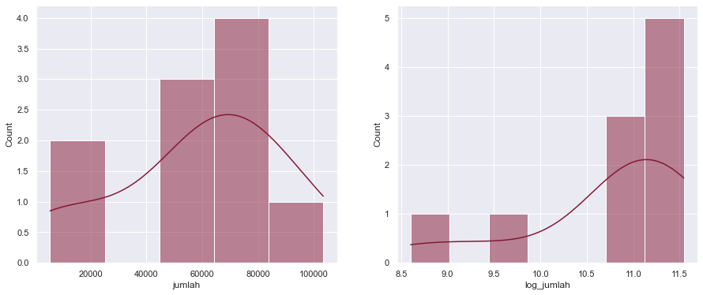

```python
fig, (ax1, ax2) = plt.subplots(1, 2, figsize=(15,6))
jml = df["jumlah"]
print(f'Rentang Jumlah Pengunjung Perpustakan di DKI Jakarta (2015-2019) = {jml.min()} s/d {jml.max()}')
sns.histplot(df['jumlah'], ax=ax1, kde=True)
sns.histplot(df['log_jumlah'], ax=ax2, kde=True);
```

# Feature Engineering: Derived Mathematics Features

Jenis Feature Engineering berikutnya yang digunakan untuk dataset prediksi jumlah pengunjung perpustakaan di DKI Jakarta ini adalah Derived Mathematics Features. Untuk hal tersebut, karena data yang digunakan untuk prediksi hanya 10 data pengunjung dari 2 perpustakaan, maka dapat dibentuk dalam array dengan penetapan sumbu koordinat x = Perpusda Cikini (c) dan koordinat y = Perpusda Kuningan (k), selanjutnya digunakan metode Regresi Linear Sederhana (Simple Linear Reggression)

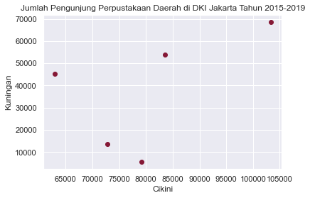

```python
c = np.array([72758,103341,83619,79114,62895])
k = np.array([13529, 68654,53821,5447,45230])
plt.xlabel("Cikini")
plt.ylabel("Kuningan")
plt.title("Jumlah Pengunjung Perpustakaan Daerah di DKI Jakarta Tahun 2015-2019")
plt.scatter(c, k);
```

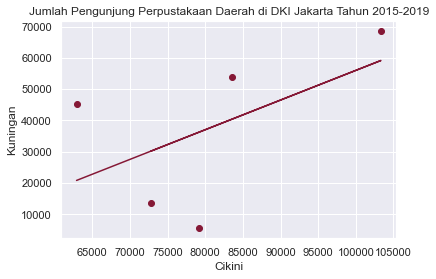

```python
from sklearn.linear_model import LinearRegression
X = c[:, np.newaxis]
model = LinearRegression().fit(X, k)
yfit = model.predict(X)
plt.xlabel("Cikini")
plt.ylabel("Kuningan")
plt.title("Jumlah Pengunjung Perpustakaan Daerah di DKI Jakarta Tahun 2015-2019")
plt.scatter(c, k)
plt.plot(c, yfit);
```

- Dari model scatterplot diatas, dapat dilihat bahwa sedikit menyulitkan untuk membaca adanya hubungan untuk kedua koordinat (sama-sama menunjukkan jumlah pengunjung), sebab meskipun sudah coba disesuaikan antara garis ke data menggunakan Linear Regression untuk mendapatkan hasil yang optimal dari hubungan diantara kedua variabel, tetap dibutuhkan suatu model feature engineering yang dapat lebih menggambarkan hubungan antara variabel c dan k.
- Salah satu pendekatan yang dapat dilakukan untuk menggambarkan hubungan tersebut adalah mengubah data dan menambahkan kolom fitur tambahan untuk menghasilkan fleksibilitas pada model yang dihasilkan. Sebagai contoh, disini digunakan fitur polinomial

```python
from sklearn.preprocessing import PolynomialFeatures
poly = PolynomialFeatures(degree=3, include_bias=False)
X2 = poly.fit_transform(X)
print(X2)
```

```
[[7.27580000e+04 5.29372656e+09 3.85160957e+14]
 [1.03341000e+05 1.06793623e+10 1.10361598e+15]
 [8.36190000e+04 6.99213716e+09 5.84675517e+14]
 [7.91140000e+04 6.25902500e+09 4.95176504e+14]
 [6.28950000e+04 3.95578102e+09 2.48798848e+14]]
```

Matriks derived features diatas memiliki satu kolom yang mewakili x, dan kolom kedua yang mewakili x2, dan kolom ketiga yang mewakili x3. Menghitung regresi linier pada input yang diperluas ini memberikan gambaran tentang hubungan data pengunjung perpustakaan Cikini (c) dan Kuningan (k)

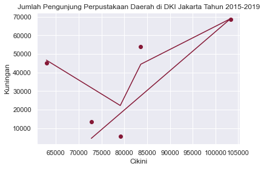

```python
model = LinearRegression().fit(X2, k)
yfit = model.predict(X2)
plt.scatter(c, k)
plt.xlabel("Cikini")
plt.ylabel("Kuningan")
plt.title("Jumlah Pengunjung Perpustakaan Daerah di DKI Jakarta Tahun 2015-2019")
plt.plot(c, yfit);
```

# Pembangunan Model

Dataset yang dipakai untuk klasifikasi adalah dataset jumlah pengunjung perpustakaan daerah Provinsi DKI Jakarta selama 5 tahun (2015-2019) dengan nama data-jumlah-pengunjung-perpustakaan-tahun-2015-2019.csv. Penjelasan mengenai variabel pada dataset ini:

tahun : Tahun perpustakaan : Nama Perpustakaan jumlah : Jumlah Pengunjung Dataset ini berasal dari tahun 2015 s.d. 2019.

```python
import os
import glob
import pandas as pd
import numpy as np
import matplotlib.pyplot as plt
import seaborn as sns
from sklearn import datasets
from contextlib import contextmanager
extension = 'csv'
path = 'data-jumlah-pengunjung-perpustakaan-tahun-2015-2019.csv'
os.chdir('D:/finalsimplelinreg-main')
df = pd.read_csv(path)
df.head()
```

|  | tahun | perpustakaan | jumlah | tahun.1 | perpustakaan.1 | jumlah.1 | tahun.2 | perpustakaan.2 | jumlah.2 | tahun.3 | perpustakaan.3 | jumlah.3 | tahun.4 | perpustakaan.4 | jumlah.4 |
| --- | --- | --- | --- | --- | --- | --- | --- | --- | --- | --- | --- | --- | --- | --- | --- |
| 0 | 2015 | Cikini | 72758.0 | 2016 | Cikini | 103341.0 | 2017 | Cikini | 83619.0 | 2018 | Cikini | 79114 | 2019 | Cikini | 62895 |
| 1 | 2015 | Kuningan | 13529.0 | 2016 | Kuningan | 68654.0 | 2017 | Kuningan | 53821.0 | 2018 | Kuningan | 5447 | 2019 | Kuningan | 45230 |
| 2 | 2015 | PDS HB Jassin | 0.0 | 2016 | PDS HB Jassin | 0.0 | 2017 | PDS HB Jassin | 0.0 | 2018 | PDS HB Jassin | 2749 | 2019 | PDS HB Jassin | 5319 |
| 3 | 2015 | Perpustakaan Digital iJakarta | 0.0 | 2016 | Perpustakaan Digital iJakarta | 0.0 | 2017 | Perpustakaan Digital iJakarta | 0.0 | 2018 | Perpustakaan Digital iJakarta | 20736 | 2019 | Perpustakaan Digital iJakarta | 21999 |
| 4 | 2015 | Sudin Pusip Jakpus (Stationary) | 15108.0 | 2016 | Sudin Pusip Jakpus (Stationary) | 91807.0 | 2017 | Sudin Pusip Jakpus (Stationary) | 20411.0 | 2018 | Sudin Pusip Jakpus (Stationary) | 23719 | 2019 | Sudin Pusip Jakpus (Stationary) | 36767 |

```python
X = df[['jumlah.2']]
y = df[['jumlah']]
print("Banyak data: ", len(X))
print("20 data pertama: ")
print(X[:20])
print("20 label pertama: ")
print(y[:20])
```

```
Banyak data:  23
20 data pertama:
    jumlah.2
0    83619.0
1    53821.0
2        0.0
3        0.0
4    20411.0
5   105747.0
6        0.0
7     2877.0
8    46985.0
9        0.0
10   32509.0
11   66570.0
```

[output cut: 30 more lines]

Pembagian data menggunakan Train-Validation split dimana data latih = 80% dan data uji = 20%, dengan nilai random_seed = 16 Dilakukan klasifikasi dengan beberapa metode.a.l:

1. Logistic Regression
2. Naive Bayes
3. K Neaerest Neighbors
4. Decision Tree
5. SVM

```python
from sklearn.model_selection import train_test_split
np.random.seed(16)
X_train, X_test, y_train, y_test = train_test_split(X, y, train_size = 0.8)
print("Banyak data latih setelah dilakukan Train-Validation Split: ", len(X_train))
print("Banyak data uji setelah dilakukan Train-Validation Split: ", len(X_test))
```

```
Banyak data latih setelah dilakukan Train-Validation Split:  18
Banyak data uji setelah dilakukan Train-Validation Split:  5
```

```python
from sklearn.linear_model import LogisticRegression
from sklearn import naive_bayes
from sklearn.neighbors import KNeighborsClassifier
from sklearn.tree import DecisionTreeClassifier
from sklearn.svm import SVC
from sklearn import metrics

lr = LogisticRegression()
lr.fit(X_train, y_train)
y_pred = lr.predict(X_test)
score = metrics.accuracy_score(y_test, y_pred)
print("Akurasi dengan menggunakan Logistic Regression: ", score)



nb = naive_bayes.BernoulliNB()
nb.fit(X_train, y_train)
y_pred = nb.predict(X_test)
score = metrics.accuracy_score(y_test, y_pred)
print("Akurasi dengan menggunakan Naive Bayes: ", score)


knn = KNeighborsClassifier()
knn.fit(X_train, y_train)
y_pred = knn.predict(X_test)
score = metrics.accuracy_score(y_test, y_pred)
print("Akurasi dengan menggunakan Nearest Neighbor: ", score)

dt = DecisionTreeClassifier(
  max_depth = 1,
  min_samples_split = 2
)
dt.fit(X_train, y_train)
y_pred = dt.predict(X_test)
score = metrics.accuracy_score(y_test, y_pred)
print("Akurasi dengan menggunakan Decision Tree: ", score)


svm = SVC(
  kernel = 'rbf',
  C = 1,
  gamma = 0.01
)
svm.fit(X_train, y_train)
y_pred = svm.predict(X_test)
score = metrics.accuracy_score(y_test, y_pred)
print("Akurasi dengan menggunakan Support Vector Machine: ", score)
```

```
Akurasi dengan menggunakan Logistic Regression:  0.6
Akurasi dengan menggunakan Naive Bayes:  0.6
Akurasi dengan menggunakan Nearest Neighbor:  0.6
Akurasi dengan menggunakan Decision Tree:  0.6
Akurasi dengan menggunakan Support Vector Machine:  0.6
```

## Model Regresi Linier Sederhana

```python
df = pd.read_csv(path)
df = df.rename(columns = {'jumlah.1': 'jumlah_1', 'jumlah.2': 'jumlah_2','jumlah.3': 'jumlah_3', 'jumlah.4': 'jumlah_4'},
                      inplace = False)
df.describe()
```

|  | tahun | jumlah | tahun.1 | jumlah_1 | tahun.2 | jumlah_2 | tahun.3 | jumlah_3 | tahun.4 | jumlah_4 |
| --- | --- | --- | --- | --- | --- | --- | --- | --- | --- | --- |
| count | 23.0 | 23.000000 | 23.0 | 23.000000 | 23.0 | 23.000000 | 23.0 | 23.000000 | 23.0 | 23.000000 |
| mean | 2015.0 | 13563.739130 | 2016.0 | 45019.652174 | 2017.0 | 30167.043478 | 2018.0 | 133296.695652 | 2019.0 | 160377.826087 |
| std | 0.0 | 17766.644435 | 0.0 | 36754.497763 | 0.0 | 32353.815902 | 0.0 | 184958.542279 | 0.0 | 168648.641240 |
| min | 2015.0 | 0.000000 | 2016.0 | 0.000000 | 2017.0 | 0.000000 | 2018.0 | 683.000000 | 2019.0 | 5319.000000 |
| 25% | 2015.0 | 0.000000 | 2016.0 | 19526.500000 | 2017.0 | 0.000000 | 2018.0 | 21813.500000 | 2019.0 | 33390.000000 |
| 50% | 2015.0 | 8579.000000 | 2016.0 | 42385.000000 | 2017.0 | 20411.000000 | 2018.0 | 47328.000000 | 2019.0 | 62895.000000 |
| 75% | 2015.0 | 18823.000000 | 2016.0 | 58874.500000 | 2017.0 | 55788.000000 | 2018.0 | 145316.500000 | 2019.0 | 257046.500000 |
| max | 2015.0 | 72758.000000 | 2016.0 | 142919.000000 | 2017.0 | 105747.000000 | 2018.0 | 691603.000000 | 2019.0 | 534462.000000 |

```python
cdf = df[['jumlah','jumlah_1','jumlah_2','jumlah_3','jumlah_4']]
cdf.head(20)
```

|  | jumlah | jumlah_1 | jumlah_2 | jumlah_3 | jumlah_4 |
| --- | --- | --- | --- | --- | --- |
| 0 | 72758.0 | 103341.0 | 83619.0 | 79114 | 62895 |
| 1 | 13529.0 | 68654.0 | 53821.0 | 5447 | 45230 |
| 2 | 0.0 | 0.0 | 0.0 | 2749 | 5319 |
| 3 | 0.0 | 0.0 | 0.0 | 20736 | 21999 |
| 4 | 15108.0 | 91807.0 | 20411.0 | 23719 | 36767 |
| 5 | 24717.0 | 64336.0 | 105747.0 | 154044 | 196689 |
| 6 | 0.0 | 43152.0 | 0.0 | 219972 | 357184 |
| 7 | 13211.0 | 17755.0 | 2877.0 | 22891 | 29159 |
| 8 | 47509.0 | 46829.0 | 46985.0 | 135195 | 279240 |
| 9 | 0.0 | 101456.0 | 0.0 | 39194 | 363273 |
| 10 | 28384.0 | 26211.0 | 32509.0 | 47328 | 45374 |
| 11 | 0.0 | 53413.0 | 66570.0 | 237715 | 234853 |
| 12 | 0.0 | 142919.0 | 0.0 | 511065 | 461598 |
| 13 | 18956.0 | 25662.0 | 28923.0 | 28955 | 34063 |
| 14 | 18690.0 | 25040.0 | 57755.0 | 683 | 165535 |
| 15 | 0.0 | 42385.0 | 0.0 | 475141 | 459210 |
| 16 | 18548.0 | 43966.0 | 22027.0 | 37791 | 32717 |
| 17 | 20609.0 | 40712.0 | 77320.0 | 109919 | 107136 |
| 18 | 0.0 | 21298.0 | 0.0 | 691603 | 534462 |
| 19 | 8579.0 | 48376.0 | 58916.0 | 65658 | 51743 |

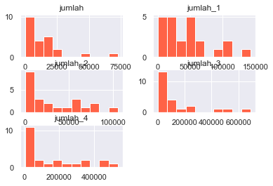

```python
viz = cdf[['jumlah','jumlah_1','jumlah_2','jumlah_3','jumlah_4']]
viz.hist(color='tomato')
plt.show()
```

Dataset pelatihan dapat digunakan untuk membuat model, serta dataset pengujian untuk pengujian, digunakan nilai random seed = 12

```python
np.random.seed(12)
msk = np.random.rand(len(df)) < 0.8
train = cdf[msk]
test = cdf[~msk]
msk
```

```
array([ True,  True,  True,  True,  True, False, False,  True, False,
        True,  True,  True, False, False,  True,  True,  True,  True,
        True,  True,  True,  True,  True])
```

```python
train.shape
```

```
(18, 5)
```

```python
test.shape
```

```
(5, 5)
```

Untuk model regeresi linier sederhana, menggunakan distribusi data pelatihan (training) berupa jumlah data pengunjung perpustakaan DKI Jakarta di 2 tahun terakhir, yakni tahun 2018 dan 2019

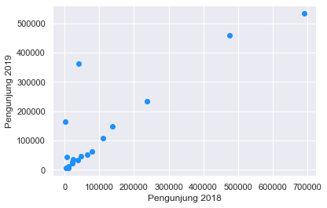

|  | jumlah | jumlah_1 | jumlah_2 | jumlah_3 | jumlah_4 |
| --- | --- | --- | --- | --- | --- |
| 0 | 72758.0 | 103341.0 | 83619.0 | 79114 | 62895 |
| 1 | 13529.0 | 68654.0 | 53821.0 | 5447 | 45230 |
| 2 | 0.0 | 0.0 | 0.0 | 2749 | 5319 |

```python
plt.scatter(train.jumlah_3, train.jumlah_4,  color='dodgerblue')
plt.xlabel("Pengunjung 2018")
plt.ylabel("Pengunjung 2019")
plt.show()
train.head(3)
```

```python
from sklearn import linear_model
regr = linear_model.LinearRegression()
train_x = np.asanyarray(train[['jumlah_3']])
train_y = np.asanyarray(train[['jumlah_4']])
regr.fit (train_x, train_y)
# The coefficients
print ('Coefficients: ', regr.coef_)
print ('Intercept: ',regr.intercept_)
```

```
Coefficients:  [[0.75424602]]
Intercept:  [46606.04171256]
```

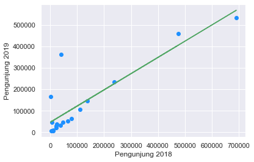

```python
plt.scatter(train.jumlah_3, train.jumlah_4,  color='dodgerblue')
plt.plot(train_x, regr.coef_[0][0]*train_x + regr.intercept_[0], '-g')
plt.xlabel("Pengunjung 2018")
plt.ylabel("Pengunjung 2019")
```

## Evaluasi Nilai Aktual & Prediksi

Evaluasi dari nilai aktual dan prediksi data pengunjung tahun 2018 dan 2019 dilakukan dengan 3 metode, yaitu:

```
Mean absolute error: 74625.99
Residual sum of squares (MSE): 8240726324.31
R2-score: 0.45
```

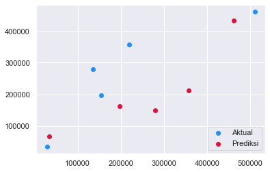

```python
from sklearn.metrics import r2_score
import matplotlib.patches as mpatches
test_x = np.asanyarray(test[['jumlah_3']])
test_y = np.asanyarray(test[['jumlah_4']])
test_y_ = regr.predict(test_x)

print("Mean absolute error: %.2f" % np.mean(np.absolute(test_y_ - test_y)))
print("Residual sum of squares (MSE): %.2f" % np.mean((test_y_ - test_y) ** 2))
print("R2-score: %.2f" % r2_score(test_y_ , test_y) )

blue_patch = plt.scatter(test.jumlah_3, test_y, color='dodgerblue', label = 'Aktual')
pink_patch = plt.scatter(test.jumlah_4, test_y_, color='crimson', label = 'Prediksi')
plt.legend(handles=[blue_patch,pink_patch],loc="lower right")
plt.show()
```

## Evaluasi Hasil Pemodelan & Prediksi Simple Linear Regression

```python
x = df['jumlah_3'].values.reshape(-1,1)
y = df['jumlah_4'].values.reshape(-1,1)

#split data pengunjung menjadi training and testing dengan pembagian 80:20
x_train, x_test, y_train, y_test = train_test_split(x, y, test_size=0.2)

#Memanfaatkan object linear regresi dengan nama variabel regr, dilakukan training dengan menggunakan training data
#data yang sudah displit sebelumnya.
regr.fit(x_train, y_train)

#Mencari nilai slope/koefisien (m) dan intercept (b)
print(regr.coef_)
print(regr.intercept_)
```

```
[[0.75891118]]
[52551.14790612]
```

Berdasarkan nilai m dan b diatas, kalau dimasukan ke dalam rumus menjadi: Y = 0.75x + 52551.14 Langkah berikutnya ialah mencari accuracy score dari model dengan menggunakan testing data yang sudah displit sebelumnya.

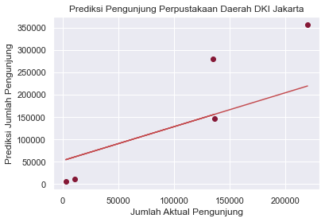

```python
regr.score(x_test, y_test) #Model mendapatkan accuracy score sebesar 60%

#Melakukan visualisasi Regression Line menggunakan data testing
y_prediksi = regr.predict(x_test)
plt.scatter(x_test, y_test)
plt.plot(x_test, y_prediksi, c='r')
plt.xlabel('Jumlah Aktual Pengunjung')
plt.ylabel('Prediksi Jumlah Pengunjung')
plt.title('Prediksi Pengunjung Perpustakaan Daerah DKI Jakarta')

#Garis berwarna merah merupakan Regression Line dari model yang telah dibuat sebelumnya
```

[output not shown]

Setelah itu dilanjutkan dengan menginputkan data prediksi jumlah pengunjung berdasarkan nilai yang diperoleh dari jumlah pengunjung di tahun-tahun sebelumnya

```python
regr.predict([[100000]])
```

```
array([[128442.26618956]])
```

```python
regr.predict([[150000]])
```

```
array([[166387.82533128]])
```

# Kesimpulan Akhir Hasil Prediksi dengan Simple Linear Regression